# Programming for FinTech

## Treasury Yield Interpolation

For example, fill the straight line estimate for “9 month” yield.

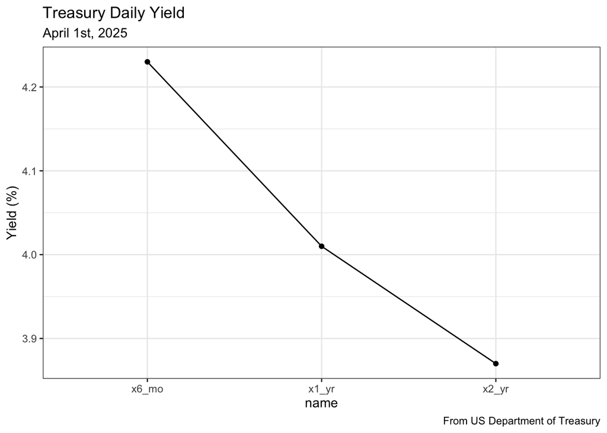

The treasury daily yield data looks like below.

```r
treasury_data <- tibble(
  date = as.Date(c("2025-04-01", "2025-04-02", "2025-04-03", "2025-04-04")),
  x6_mo = c(4.23, 4.24, 4.20, 4.14),
  x1_yr = c(4.01, 4.04, 3.92, 3.86),
  x2_yr = c(3.87, 3.91, 3.71, 3.68)
)

print(treasury_data)
```

```
# A tibble: 4 × 4
  date       x6_mo x1_yr x2_yr
  <date>     <dbl> <dbl> <dbl>
1 2025-04-01  4.23  4.01  3.87
2 2025-04-02  4.24  4.04  3.91
3 2025-04-03  4.2   3.92  3.71
4 2025-04-04  4.14  3.86  3.68
```

To interpolate, you’ll need to pivot the data and make an explicit missing value:

```r
treasury_interpolate <- treasury_data |>
    pivot_longer(cols = !date) |>
    complete(date, name = c("x6_mo", "x9_mo","x1_yr","x2_yr")) |>
    mutate(name = fct(name, levels = c("x6_mo","x9_mo","x1_yr","x2_yr"))) |> # ordering
    arrange(date, name)
treasury_interpolate
```

```
# A tibble: 16 × 3
   date       name  value
   <date>     <fct> <dbl>
 1 2025-04-01 x6_mo  4.23
 2 2025-04-01 x9_mo NA
 3 2025-04-01 x1_yr  4.01
 4 2025-04-01 x2_yr  3.87
 5 2025-04-02 x6_mo  4.24
 6 2025-04-02 x9_mo NA
 7 2025-04-02 x1_yr  4.04
 8 2025-04-02 x2_yr  3.91
 9 2025-04-03 x6_mo  4.2
10 2025-04-03 x9_mo NA
11 2025-04-03 x1_yr  3.92
12 2025-04-03 x2_yr  3.71
13 2025-04-04 x6_mo  4.14
14 2025-04-04 x9_mo NA
15 2025-04-04 x1_yr  3.86
16 2025-04-04 x2_yr  3.68
```

Then, generate a numeric column to help interpolating the yield estimates.

```r
treasury_interpolate <- treasury_interpolate |>
    mutate(
        days = case_when(
            name == "x6_mo" ~ 180,
            name == "x9_mo" ~ 270,
            name == "x1_yr" ~ 360,
            name == "x2_yr" ~ 720,
        )
    )
head(treasury_interpolate)
```

```
# A tibble: 6 × 4
  date       name  value  days
  <date>     <fct> <dbl> <dbl>
1 2025-04-01 x6_mo  4.23   180
2 2025-04-01 x9_mo NA      270
3 2025-04-01 x1_yr  4.01   360
4 2025-04-01 x2_yr  3.87   720
5 2025-04-02 x6_mo  4.24   180
6 2025-04-02 x9_mo NA      270
```

Finally, interpolate with `approx()` function. Notice the use of `group_by()` in this operation.

```r
treasury_interpolate |>
    group_by(date) |>
    mutate(value_interpolated = approx(x = days, y = value, xout = days)$y)
```

```
# A tibble: 16 × 5
# Groups:   date [4]
   date       name  value  days value_interpolated
   <date>     <fct> <dbl> <dbl>              <dbl>
 1 2025-04-01 x6_mo  4.23   180               4.23
 2 2025-04-01 x9_mo NA      270               4.12
 3 2025-04-01 x1_yr  4.01   360               4.01
 4 2025-04-01 x2_yr  3.87   720               3.87
 5 2025-04-02 x6_mo  4.24   180               4.24
 6 2025-04-02 x9_mo NA      270               4.14
 7 2025-04-02 x1_yr  4.04   360               4.04
 8 2025-04-02 x2_yr  3.91   720               3.91
 9 2025-04-03 x6_mo  4.2    180               4.2
10 2025-04-03 x9_mo NA      270               4.06
11 2025-04-03 x1_yr  3.92   360               3.92
12 2025-04-03 x2_yr  3.71   720               3.71
13 2025-04-04 x6_mo  4.14   180               4.14
14 2025-04-04 x9_mo NA      270               4
15 2025-04-04 x1_yr  3.86   360               3.86
16 2025-04-04 x2_yr  3.68   720               3.68
```

## Exercise

```r
stock_returns <- tibble(
  date = as.Date(c("2023-01-01", "2023-01-02", "2023-01-03", "2023-01-04", "2023-01-05")),
  return = c(0.01, NA, -0.01, NA, 0.02)
)
```

1. Use `ifelse()` to create a new column return_filled where missing returns are filled with 0, assuming no change in stock price on those days.
2. Use `tidyr::replace_na()` to achieve the same result, replacing NA values with 0 in the return column.

```r
tesla_revenue <- tibble(
  company = "TSLA",
  year = c(2020, 2020, 2021),
  quarter = c(1, 3, 2),
  revenue = c(100, 110, 120)
)
```

3. Use `tidyr::complete()` to add the missing quarters for 2020 and 2021. Assume that each year should have quarters 1 to 4 (Q1, Q2, Q3, Q4). The missing revenue values should appear as NA.
4. Fill the missing revenue values using the LOCF method. Ensure the data is properly arranged by year and quarter before applying `tidyr::fill()`.

```r
treasury_yields <- tibble(
  maturity = c("6 Mo", "9 Mo", "1 Yr", "2 Yr"),
  days = c(180, 270, 360, 720),
  yield = c(4.23, NA, 4.01, 3.87)
)
```

5. Use the `approx()`function to interpolate the yield for “9 Mo” based on the days and yield columns. Provide the interpolated yield value as your answer.

# Character Vectors

## Strings

Characters (Strings) store text information in finance such as

- earnings announcements
- analyst opinions
- descriptions
- investment sentiments, etc.

We’ll mostly use `stringr` package (included in tidyverse)

## Generate Strings

You can create strings by wrapping values with singgle quote (`'`) or double quotes (`"`).

```r
announcement1 <- 'Tariff will be 34%'
announcement2 <- "Actually, it will be 125%!"
quote_in_quotes <- 'If you want to include "quote" inside, mix \' and \"'
```

## Print Strings

There are multiple string printing functions in R: `print()`,`cat()` and `str_view()`

- `print()` gives you full structure of underlying string
- `cat()` shows rendered string output
- `str_view()` shows rendered output (robust)

## Escape Strings

Special characters (quotes, backslash, backticks, etc.) has their reserved use, and if you want to include them, you have to escape with backslash `\`.

```r
double_quotes <- c("\"", '"')
print(double_quotes)
cat(double_quotes)
str_view(double_quotes)

backslashes <- c("\\", '\\')
print(backslashes)
cat(backslashes)
str_view(backslashes)
```

## Other Special Characters

There are some other special characters worth remembering:

- `\n` newline
- `\t` tab
- `\U` Unicode escapes

```r
x <- c("one\ntwo", "one\ttwo", "\U0001f604")
print(double_quotes) # print gives you the structure
cat(x)
str_view(x)
```

## Tricky Escapes

Creating a string with multiple quotes, backslashes, gets confusing so quickly! For example:

```r
tricky <- "
Without raw strings,
Double backslashes \\\\ and
double double quotes '\"\"' with quotes
will make you crazy."
cat(tricky)
```

```
Without raw strings,
Double backslashes \\ and
double double quotes '""' with quotes
will make you crazy.
```

This is called [Leaning Toothpick Syndrome](https://en.wikipedia.org/wiki/Leaning_toothpick_syndrome)

## Raw Strings

To eliminate escaping, you can use **raw string** with `r"()"`, `r"{}"`, `r"[]"`.

```r
not_so_tricky <- r"(
With raw strings,
writing double backslashes \\ and
double double quotes '""' wrapped with quotes
will not be so hard.
)"
cat(not_so_tricky)
```

```
With raw strings,
writing double backslashes \\ and
double double quotes '""' wrapped with quotes
will not be so hard.
```

## Exercise

Create strings that contain the following values:

- He said “We have a beautiful announcement today!”
- \a\b\c\d
- \\\

## Creating strings

`str_c()` concatenates multiple string vectors, element-wise.

```r
str_c("A", "B") # scalar
```

```
[1] "AB"
```

```r
str_c(c("a", "b"), c("c","d")) # vectorized
```

```
[1] "ac" "bd"
```

For example, combine a financial report header with

```r
str_c("Report for", c("Acme Corp", "Beta Inc"))
```

```
[1] "Report forAcme Corp" "Report forBeta Inc"
```

```r
str_c("Report for", c("Acme Corp", "Beta Inc"), sep = " ") # Use separator
```

```
[1] "Report for Acme Corp" "Report for Beta Inc"
```

## glue strings

`str_glue()` improves readability by allowing embedded expressions within {}.

```r
company <- "Microsoft Inc."
str_glue("Earnings: {company} reported strong results.")
```

```
Earnings: Microsoft Inc. reported strong results.
```

Also works with vectorized operations with recycling.

```r
companies <- c("Apple Inc.","Microsoft Inc.")
str_glue("Earnings: {companies} reported strong results.") # vectorized
```

```
Earnings: Apple Inc. reported strong results.
Earnings: Microsoft Inc. reported strong results.
```

## flatten strings

If you want to collapse a vector of strings into a single string, `str_flatten()`, or `paste()`

```r
forecast <- c("There", "will", "be", "a", "strong", "market", "volatility.")
str_flatten(forecast)
```

```
[1] "Therewillbeastrongmarketvolatility."
```

```r
str_flatten(forecast, collapse = " ") # space between collapsing
```

```
[1] "There will be a strong market volatility."
```

Base R: `paste()` and collapse.

```r
paste(forecast, collapse = " ")
```

```
[1] "There will be a strong market volatility."
```

## Exercise

1. Check out the length of the vector and length of the string of:

```r
companies <- c("Alphabet Corp", "Beta Inc", "Gamma LLC")
```

2. Flatten the above `companies` character vector into a scalar string.
3. Fix below code to evaluate embed expression `companies` then print:

```r
announcement <- "The {companies} is performing well."
print(announcement) # "companies" is not evaluated. How to fix it?
```

```
[1] "The {companies} is performing well."
```

## Letters in Strings

Two relevant concepts related to the length:

- number of elementsin a vector: `length()`
- the number of characters for each elements: `str_length()` or `nchar()`

```r
example_string <- c("risk free rates", "earnings announcements")
length(example_string)
```

```
[1] 2
```

```r
str_length(example_string)
```

```
[1] 15 22
```

```r
nchar(example_string)
```

```
[1] 15 22
```

## Subsetting Letters

You can extract parts of a string using position arguements with `str_sub()`

```r
companies <- c("Apple Inc.", "Sackson LLC", "Zeta Investments")
str_sub(companies, 1, 2)
```

```
[1] "Ap" "Sa" "Ze"
```

```r
str_sub(companies, -1) # last letter
```

```
[1] "." "C" "s"
```

```r
str_sub(companies, 5, -1) # 5th to last
```

```
[1] "e Inc."       "son LLC"      " Investments"
```

```r
str_sub(companies, -5, -1) # last 5th to last
```

```
[1] " Inc." "n LLC" "ments"
```

## Pad strings

`str_pad()` pads a string to fixed length by adding extra whitespace on the left, right or both.

```r
x <- c("Apple", "Microsoft")
str_pad(x, 10) # makes 10 character by adding whitespace on left
```

```
[1] "     Apple" " Microsoft"
```

```r
str_pad(x, 10, side = "right")
```

```
[1] "Apple     " "Microsoft "
```

```r
str_pad(x, 10, side = "both")
```

```
[1] "  Apple   " "Microsoft "
```

You can pad other strings, for example, leading zeros:

```r
number_string <- c("1","23","359")
str_pad(number_string, width = 3, pad = "0") # 3 character with leading zeros
```

```
[1] "001" "023" "359"
```

## Lettercases

Upper / lowercase transfromations:

```r
x <- "Economists say that it can cause stagflation."
str_to_upper(x) # uppercase
```

```
[1] "ECONOMISTS SAY THAT IT CAN CAUSE STAGFLATION."
```

```r
str_to_lower(x) # lowercase
```

```
[1] "economists say that it can cause stagflation."
```

```r
str_to_title(x) # Title cases
```

```
[1] "Economists Say That It Can Cause Stagflation."
```

## Exercises

```r
companies <- c("Apple Inc.", "Sackson LLC", "Zeta Investments")
```

1. Extract the first two characters from `companies`.
2. Extract the last two characters.
3. Transform to lowercases and uppercases.

```r
number_string <- c("1","23","359")
```

4. Pad “0” to the left so that it has 4 letters (e.g, “0001”).

# Regular Expressions

## RegEx

Regular Expressions (Regex) is a language for describing **“patterns”** within strings.

- Regex is a core tool for working with text data
- Widely supported in `stringr`, tidyverse, and base R

## Prep

We’ll use regular expression functions from the `stringr` and `tidyr` packages, both core members of the `tidyverse`.

```r
# install.packages("newsanchor")
library(tidyverse)
library(newsanchor) # For financial news data
```

## Datasets and Examples

To explore regular expressions, we’ll use:

Three character vectors from the `stringr` package:

- `fruit`: names of 80 fruits
- `words`: 980 common English words
- `sentences`: 720 short example sentences

These built-in datasets are great for testing regex.

## Pattern Basics

`str_view()` highlights matches in a string vector using `<>`.

Literal characters match exactly:

```r
str_view(fruit, "berry")
```

```
 [6] │ bil<berry>
 [7] │ black<berry>
[10] │ blue<berry>
[11] │ boysen<berry>
[19] │ cloud<berry>
[21] │ cran<berry>
[29] │ elder<berry>
[32] │ goji <berry>
[33] │ goose<berry>
[38] │ huckle<berry>
[50] │ mul<berry>
[70] │ rasp<berry>
[73] │ salal <berry>
[76] │ straw<berry>
```

## Metacharacters and Wildcards

Some characters, like `.`, `+`, and `*`, have special meanings in regex and are known as **metacharacters**.

`.`: A wildcard that matches any **single** character. For example:

```r
str_view(c("a", "ab", "ae", "bd", "ea", "eab"), "a.")
```

```
[2] │ <ab>
[3] │ <ae>
[6] │ e<ab>
```

## Pattern Length with Wildcards

You can match specific lengths of text using `.` repeated:

```r
str_view(fruit, "a...e")
```

```
 [1] │ <apple>
 [7] │ bl<ackbe>rry
[48] │ mand<arine>
[51] │ nect<arine>
[62] │ pine<apple>
[64] │ pomegr<anate>
[70] │ r<aspbe>rry
[73] │ sal<al be>rry
```

This matches an “a” followed by any three characters and an “e”.

## Quantifiers

Quantifiers control how often a pattern appears:

- `?`: 0 or 1 time (optional)

```r
str_view(c("a", "ab", "abb", "abbb", "abc"), "ab?") # ? applied to "b"
```

```
[1] │ <a>
[2] │ <ab>
[3] │ <ab>b
[4] │ <ab>bb
[5] │ <ab>c
```

- `+`: 1 or more times

```r
str_view(c("a", "ab", "abb", "abbb", "abc"), "ab+") # + applied to "b"
```

```
[2] │ <ab>
[3] │ <abb>
[4] │ <abbb>
[5] │ <ab>c
```

- `*`: 0 or more times

```r
str_view(c("a", "ab", "abb", "abbb", "abc"), "ab*") # * applied to "b"
```

```
[1] │ <a>
[2] │ <ab>
[3] │ <abb>
[4] │ <abbb>
[5] │ <ab>c
```

## Exercise

```r
my_words <- c("ca", "oca", "caan", "cat", "call", "candy")
```

1. Use `str_view()` to highlight pattern “ca”
2. Use `str_view()` to highlight pattern “ca” and following exactly one character (hint: `.`)

## Character Set

Use brackets `[]` to define and match sets of characters. It is also called as character class. For example, `[aeiou]` matches any vowel.

```r
str_view(words, "[aeiou]x[aeiou]") # Words containing x surrounded by vowels
```

```
[284] │ <exa>ct
[285] │ <exa>mple
[288] │ <exe>rcise
[289] │ <exi>st
```

```r
str_view(words, "[^aeiou]y[^aeiou]") # Words containing y surrounded by consonants
```

```
[836] │ <sys>tem
[901] │ <typ>e
```

The caret `^` *inside brackets* **negates** the set.

**Caution**

The caret `^` **outside of brackets** has a different meaning: it anchors the match to the **beginning of the string**.

## Alternation (OR)

Use `|` to match one of several patterns:

```r
str_view(fruit, "apple|melon|nut")
```

```
 [1] │ <apple>
[13] │ canary <melon>
[20] │ coco<nut>
[52] │ <nut>
[62] │ pine<apple>
[72] │ rock <melon>
[80] │ water<melon>
```

```r
str_view(fruit, "aa|ee|ii|oo|uu")
```

```
 [9] │ bl<oo>d orange
[33] │ g<oo>seberry
[47] │ lych<ee>
[66] │ purple mangost<ee>n
```

This finds fruits containing specified keywords or repeated vowels.

## Exercise

```r
another_words <- c("taxi", "flux", "pixie", "axial", "exude")
```

1. Use `str_view()` to highlight patten where “x” is surrounded by vowels
2. Use `str_view()` to match words containing any of “flux” or “pixie”

## Key functions

`str_view()` is good to experiment on pattern matching. Other key functions are:

- `str_detect()`: logical check if pattern exists
- `str_subset()`: subset elements that contains patterns
- `str_count()`: count the occurrence of pattern
- `str_replace()`: replace patterns
- `separate_...()`: separate by pattterns

## Use case: Detect Matches

In real data, you can use `str_detect()` to check for the presence of a pattern.

- It returns logical vector; ideal for filtering

```r
str_detect(c("a", "b", "c"), "[aeiou]")
```

```
[1]  TRUE FALSE FALSE
```

## `str_subset()` and `str_which()`

Two other useful functions are:

- `str_subset()`: returns the elements that contains pattern
- `str_which()`: returns the number index of elements that has pattern

Example:

```r
str_subset(sentences, "is") |> head()
```

```
[1] "These days a chicken leg is a rare dish."
[2] "Rice is often served in round bowls."
[3] "A large size in stockings is hard to sell."
[4] "A rod is used to catch pink salmon."
[5] "The source of the huge river is the clear spring."
[6] "The fish twisted and turned on the bent hook."
```

```r
str_which(sentences, "is") |> head()
```

```
[1]  4  5 10 12 13 22
```

```r
# sentences[str_which(sentences, "is")]
```

You can use these to extract or locate matches without altering the original data structure.

## Count Matches with `str_count()`

Check for repeated sequences:

```r
str_count("Dogecoin is showing signs of strength that is related", "is")
```

```
[1] 2
```

Count the number of matches per string:

```r
str_view("Dogecoin is showing signs of strength that is related", "is")
```

```
[1] │ Dogecoin <is> showing signs of strength that <is> related
```

## Case Sensitivity in Regex

You can fix this in three ways:

- Add uppercase characters to the pattern:

```r
name <- "Aaban"
str_view(name, "[aeiouAEIOU]")
```

```
[1] │ <A><a>b<a>n
```

- Use `regex(..., ignore_case = TRUE)`:

```r
str_view(name, regex("[aeiou]", ignore_case = TRUE))
```

```
[1] │ <A><a>b<a>n
```

- Preprocess the string to lowercase:

```r
str_view(str_to_lower(name), "[aeiou]")
```

```
[1] │ <a><a>b<a>n
```

## Replace Values

`str_replace()` replaces the first match. `str_replace_all()` replaces all match.

```r
x <- c("apple", "pear", "banana")
str_replace(x, "[aeiou]", "-")
```

```
[1] "-pple"  "p-ar"   "b-nana"
```

```r
str_replace_all(x, "[aeiou]", "-")
```

```
[1] "-ppl-"  "p--r"   "b-n-n-"
```

## Extract and Separate Variables

In tibble (dataframe), you can separate text into variables by

- `delimiter`,
- `position` and
- `pattern` (regex)

## Separate by delimiter

`separate_longer_delim()` separates values into long form.

```r
df1 <- tibble(x = c("a,b,c", "d,e", "f"))
df1 |>
  separate_longer_delim(x, delim = ",")
```

```
# A tibble: 6 × 1
  x
  <chr>
1 a
2 b
3 c
4 d
5 e
6 f
```

`separate_wider_delim()` separates values into wide form. You must specify `names`, and actions if too few or too many.

```r
df1 |>
  separate_wider_delim(
    x,
    delim = ",",
    names = c("first","second","third"),
    too_few = "align_start")
```

```
# A tibble: 3 × 3
  first second third
  <chr> <chr>  <chr>
1 a     b      c
2 d     e      <NA>
3 f     <NA>   <NA>
```

```r
df1 |>
  separate_wider_delim(
    x,
    delim = ",",
    names = c("first","second"),
    too_few = "align_start",
    too_many = "debug")
```

```
# A tibble: 3 × 6
  first second x     x_ok  x_pieces x_remainder
  <chr> <chr>  <chr> <lgl>    <int> <chr>
1 a     b      a,b,c FALSE        3 ",c"
2 d     e      d,e   TRUE         2 ""
3 f     <NA>   f     TRUE         1 ""
```

## Separate by position

`separate_longer_position()` splits by fixed width. Must specify `width`.

```r
df2 <- tibble(x = c("1211", "131", "21"))
df2 |>
  separate_longer_position(x, width = 2)
```

```
# A tibble: 5 × 1
  x
  <chr>
1 12
2 11
3 13
4 1
5 21
```

`separate_wider_position()` separates values into wide form.

You must specify `widths` with named integer vector, and actions if too few or too many.

```r
df3 <- tibble(x = c("202215TX", "202122LA", "202325CA"))
df3 |>
  separate_wider_position(
    x,
    widths = c(year = 4, age = 2, state = 2))
```

```
# A tibble: 3 × 3
  year  age   state
  <chr> <chr> <chr>
1 2022  15    TX
2 2021  22    LA
3 2023  25    CA
```

## Separate by regex

When you want to separate by regex patterns. Below is a complex sample:

```r
df <- tribble(
  ~string,
  "<Sheryl>-F_34",
  "<Kisha>-F_45",
  "<Brandon>-M_33",
  "<Sharon>-F_38"
)
print(df)
```

```
# A tibble: 4 × 1
  string
  <chr>
1 <Sheryl>-F_34
2 <Kisha>-F_45
3 <Brandon>-M_33
4 <Sharon>-F_38
```

Use `separate_wider_regex()` to extract structured data:

```r
df |>
  separate_wider_regex(
    string,
    patterns = c(
      "<",
      name = "[A-Za-z]+",
      ">-",
      gender = ".",
      "_",
      age = "[0-9]+"
    )
  )
```

```
# A tibble: 4 × 3
  name    gender age
  <chr>   <chr>  <chr>
1 Sheryl  F      34
2 Kisha   F      45
3 Brandon M      33
4 Sharon  F      38
```

## Exercise

```r
test_strings <- c("apple", "banana", "cherry", "date", "fig", "grape123")
```

1. `str_detect()` to indicate whether each string contains a digit (hint [0-9]).
2. `str_count()` to count the number of vowels.
3. `str_replace_all()` to replace “a” to “e”
4. `separate_wider` to separate `fruit` to two variables by whitespace.
- Generate tibble from `fruit` first

## Escaping

To literally match metacharacters (`.`, `?`, `*`) in regex, use `\`.

- To literal match `.`, regex pattern should be `\.`
- Regex patterns are given in *strings*
- However, *strings* also escape `\` with `\`
- You should use `"\\."` to express `\.`

```r
dot <- "\\."
str_view(dot) # Literally \.
```

```
[1] │ \.
```

```r
str_view(c("abc", "a.c", "bef"), pattern = "a\\.c")
```

```
[2] │ <a.c>
```

To match `?`, you need regex `\?`, and to express it `\\?`.

```r
str_view(c("Is this crazy?"), "\\?")
```

```
[1] │ Is this crazy<?>
```

To match `\`, you need regex `\\`, and to express it `\\\\`

```r
str_view(c("\\"), "\\\\") # wow!
```

```
[1] │ <\>
```

If you use raw strings in regex, it reduces one level of escaping.

```r
str_view(c("Is this crazy?"), r"{\?}")
```

```
[1] │ Is this crazy<?>
```

```r
str_view(c(r"(\)"), r"[\\]")
```

```
[1] │ <\>
```

Or you can escape with character set `[]` for some (not all) metacharacters.

- Still `\` cannot be used with character set

```r
str_view(c("a*c", "a?c"), "[*?]")
```

```
[1] │ a<*>c
[2] │ a<?>c
```